# IODS course project

*5.Produce the following diagnostic plots*

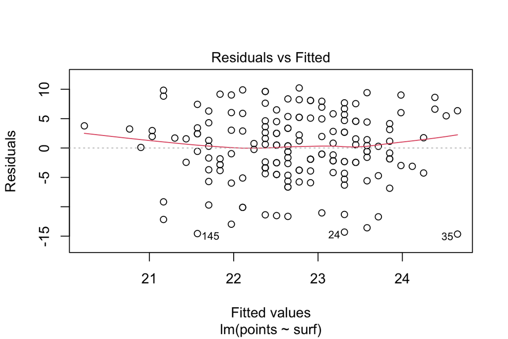

```r
#Residuals vs Fitted values
plot(lm2, which=c(1))
```

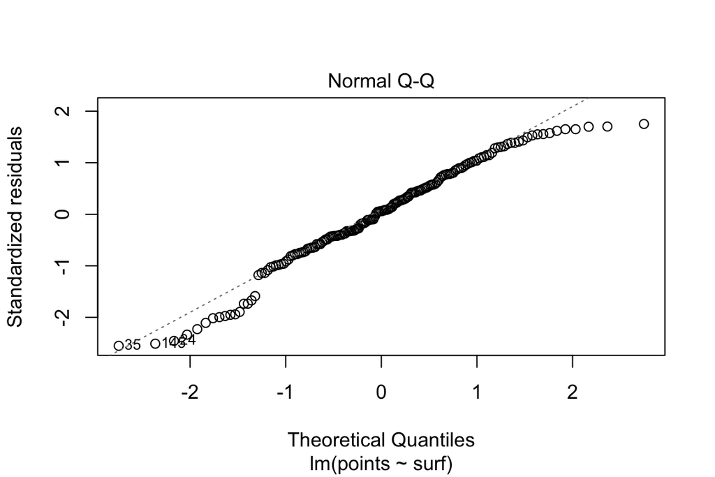

```r
#Normal QQ-plot
plot(lm2, which=c(2))
```

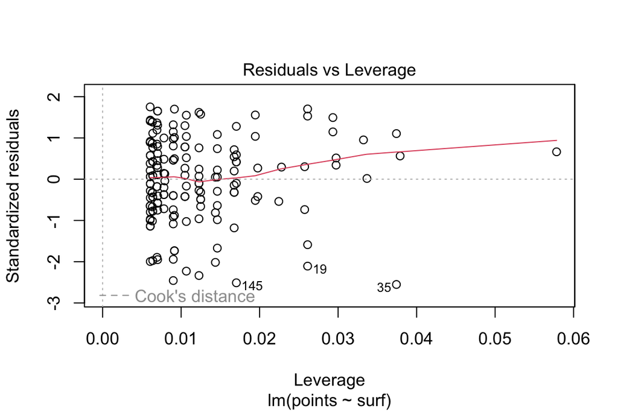

```r
#Residuals vs Leverage.
plot(lm2, which=c(5))
```

*Explain the assumptions of the model and interpret the validity of those assumptions based on the diagnostic plots.*

The first diagnostic plot ‘Residuals vs Fitted’ plots the residuals against the fitted values of the response variable ‘points’. The variability of the residuals seems rather constant across different fitted values indicating that the fitted model is appropriate. In the probability plot for residuals, Normal Q-Q, the points all mostly in a straight line. The spread of standardized residuals do not change as a function of leverage meaning that variance of the explanatory variable ‘surf’ is rather constant for different values of the outcome variable ‘points’.

```r
#install.packages("GGally")
library(tidyverse)
library(GGally)
library(ggplot2)

#alc<-read.csv("https://raw.githubusercontent.com/KimmoVehkalahti/Helsinki-Open-Data-Science/master/datasets/alc.csv", sep=";", header=TRUE)


# Alternative for downloading from working directory data folder
alc<-read.csv("data/alc.csv")

#Checking variable names
names(alc)
```

```
##  [1] "school"     "sex"        "age"        "address"    "famsize"
##  [6] "Pstatus"    "Medu"       "Fedu"       "Mjob"       "Fjob"
## [11] "reason"     "guardian"   "traveltime" "studytime"  "schoolsup"
## [16] "famsup"     "activities" "nursery"    "higher"     "internet"
## [21] "romantic"   "famrel"     "freetime"   "goout"      "Dalc"
## [26] "Walc"       "health"     "failures"   "paid"       "absences"
## [31] "G1"         "G2"         "G3"         "alc_use"    "high_use"
```

This data illustrate student achievement in secondary education of two Portuguese schools. Two datasets are provided for the performance in mathematics (mat) and Portuguese language (por). The data was acquired using school reports and questionnaires.

The aim of this analysis is to find associations between levels of alcohol consumption and other variables in the data set. Here we focus on the relationship of high and low alcohol consumption with age, travel time between home and school, weekly study time and number of past class failures. We hypothesize that age and past class failures are positively correlated with high alcohol consumption while study time might be negatively correlated. Travel time should not have any impact on alcohol consumption.

```r
#Exploring the distributions of the chosen variables and their relationships with alcohol consumption: age

#Age vs high alcohol use, create cross-table for high and low alcohol use based on age
alc %>%
  group_by(high_use, age) %>%
  tally() %>%
  spread(high_use, n)
```

```
## # A tibble: 7 × 3
##     age `FALSE` `TRUE`
##   <int>   <int>  <int>
## 1    15      63     18
## 2    16      74     28
## 3    17      62     35
## 4    18      52     25
## 5    19       7      4
## 6    20       1     NA
## 7    22      NA      1
```

```r
#create linear regression model
lm_age <-lm(high_use~age,data = alc)
summary(lm_age)
```

```
##
## Call:
## lm(formula = high_use ~ age, data = alc)
##
## Residuals:
##     Min      1Q  Median      3Q     Max
## -0.4405 -0.3174 -0.2764  0.6416  0.7646
##
## Coefficients:
##             Estimate Std. Error t value Pr(>|t|)
## (Intercept) -0.37994    0.33479  -1.135   0.2572
## age          0.04102    0.02015   2.036   0.0425 *
## ---
## Signif. codes:  0 '***' 0.001 '**' 0.01 '*' 0.05 '.' 0.1 ' ' 1
##
## Residual standard error: 0.4569 on 368 degrees of freedom
## Multiple R-squared:  0.01114,    Adjusted R-squared:  0.008452
## F-statistic: 4.145 on 1 and 368 DF,  p-value: 0.04246
```

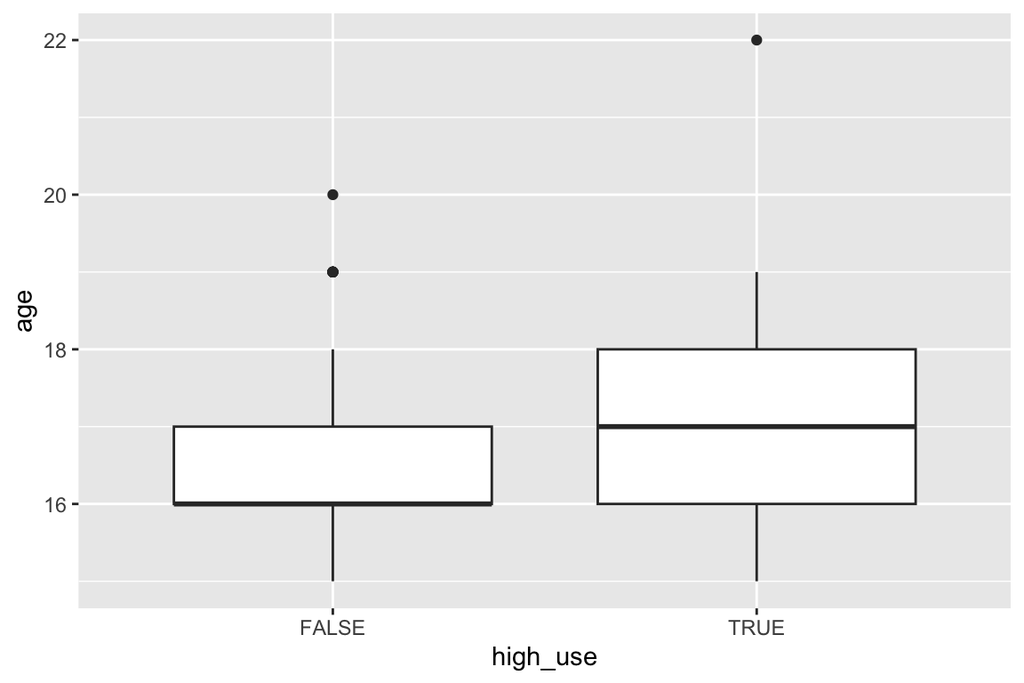

```r
#Create box-plot
g1 <- ggplot(alc, aes(x = high_use, y = age))

# define the plot as a boxplot and draw it
g1 + geom_boxplot() + ylab("age")
```

Based on the cross table, students were 15-22 years old, most students report low alcohol consumption. The number of students reporting low alcohol use is higher towards younger age. According to the linear regression model age is statistically significantly associated with high alcohol consumption. The box plot illustrates that students reporting high alcohol use tend to be older.

```r
#Exploring the distributions of the chosen variables and their relationships with alcohol consumption: traveltime

#travel time vs high alcohol use, create cross-table for high and low alcohol use based on traveltime
alc %>%
  group_by(high_use, traveltime) %>%
  tally() %>%
  spread(high_use, n)
```

```
## # A tibble: 4 × 3
##   traveltime `FALSE` `TRUE`
##        <int>   <int>  <int>
## 1          1     174     68
## 2          2      73     26
## 3          3      10     11
## 4          4       2      6
```

```r
#create linear regression model
lm_traveltime <-lm(high_use~traveltime,data = alc)
summary(lm_traveltime)
```

```
##
## Call:
## lm(formula = high_use ~ traveltime, data = alc)
##
## Residuals:
##     Min      1Q  Median      3Q     Max
## -0.5323 -0.2594 -0.2594  0.6496  0.7406
##
## Coefficients:
##             Estimate Std. Error t value Pr(>|t|)
## (Intercept)  0.16849    0.05428   3.104  0.00205 **
## traveltime   0.09095    0.03378   2.692  0.00742 **
## ---
## Signif. codes:  0 '***' 0.001 '**' 0.01 '*' 0.05 '.' 0.1 ' ' 1
##
## Residual standard error: 0.455 on 368 degrees of freedom
## Multiple R-squared:  0.01931,    Adjusted R-squared:  0.01665
## F-statistic: 7.247 on 1 and 368 DF,  p-value: 0.007425
```

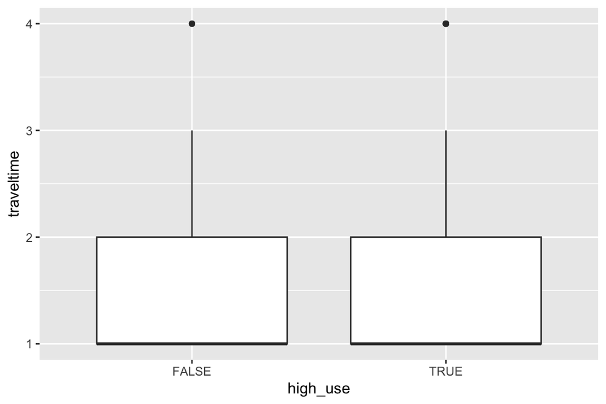

```r
#Create box-plot
g2 <- ggplot(alc, aes(x = high_use, y = traveltime))

# define the plot as a boxplot and draw it
g2 + geom_boxplot() + ylab("traveltime")
```

Travel time is given numeric values from 1 to 4 based on following: 1 - <15 min., 2 - 15 to 30 min., 3 - 30 min. to 1 hour, or 4 - >1 hour. Most students have a less than 15 minute commute to school. According to the linear regression model travel time is positively correlated with high alcohol consumption and the association is statistically significant.

```r
#Exploring the distributions of the chosen variables and their relationships with alcohol consumption: studytime

#study time time vs high alcohol use, create cross-table for high and low alcohol use based on study time
alc %>%
  group_by(high_use, studytime) %>%
  tally() %>%
  spread(high_use, n)
```

```
## # A tibble: 4 × 3
##   studytime `FALSE` `TRUE`
##       <int>   <int>  <int>
## 1         1      56     42
## 2         2     128     57
## 3         3      52      8
## 4         4      23      4
```

```r
#create linear regression model
lm_studytime <-lm(high_use~studytime,data = alc)
summary(lm_studytime)
```

```
##
## Call:
## lm(formula = high_use ~ studytime, data = alc)
##
## Residuals:
##     Min      1Q  Median      3Q     Max
## -0.4211 -0.3050 -0.1889  0.5789  0.9272
##
## Coefficients:
##             Estimate Std. Error t value Pr(>|t|)
## (Intercept)  0.53720    0.06094   8.815  < 2e-16 ***
## studytime   -0.11609    0.02755  -4.213 3.17e-05 ***
## ---
## Signif. codes:  0 '***' 0.001 '**' 0.01 '*' 0.05 '.' 0.1 ' ' 1
##
## Residual standard error: 0.4488 on 368 degrees of freedom
## Multiple R-squared:  0.04602,    Adjusted R-squared:  0.04343
## F-statistic: 17.75 on 1 and 368 DF,  p-value: 3.17e-05
```

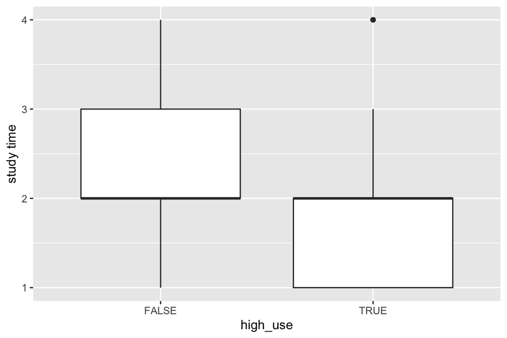

```r
#Create box-plot
g3 <- ggplot(alc, aes(x = high_use, y = studytime))

# define the plot as a boxplot and draw it
g3 + geom_boxplot() + ylab("study time")
```

Weekly study time is given numeric values from 1 to 4 based on following: 1 - <2 hours, 2 - 2 to 5 hours, 3 - 5 to 10 hours, or 4 - >10 hours. Most students study 2 to 5 hours per week. According to the linear regression model study time is negatively correlated with high alcohol consumption and the association is statistically significant.

```r
#Exploring the distributions of the chosen variables and their relationships with alcohol consumption: failures

#study time time vs high alcohol use, create cross-table for high and low alcohol use based on study time
alc %>%
  group_by(high_use, failures) %>%
  tally() %>%
  spread(high_use, n)
```

```
## # A tibble: 4 × 3
##   failures `FALSE` `TRUE`
##      <int>   <int>  <int>
## 1        0     238     87
## 2        1      12     12
## 3        2       8      9
## 4        3       1      3
```

```r
#create linear regression model
lm_failures <-lm(high_use~failures,data = alc)
summary(lm_failures)
```

```
##
## Call:
## lm(formula = high_use ~ failures, data = alc)
##
## Residuals:
##     Min      1Q  Median      3Q     Max
## -0.7409 -0.2703 -0.2703  0.5728  0.7297
##
## Coefficients:
##             Estimate Std. Error t value Pr(>|t|)
## (Intercept)  0.27033    0.02477  10.915  < 2e-16 ***
## failures     0.15685    0.04211   3.725 0.000226 ***
## ---
## Signif. codes:  0 '***' 0.001 '**' 0.01 '*' 0.05 '.' 0.1 ' ' 1
##
## Residual standard error: 0.4511 on 368 degrees of freedom
## Multiple R-squared:  0.03634,    Adjusted R-squared:  0.03372
## F-statistic: 13.88 on 1 and 368 DF,  p-value: 0.0002259
```

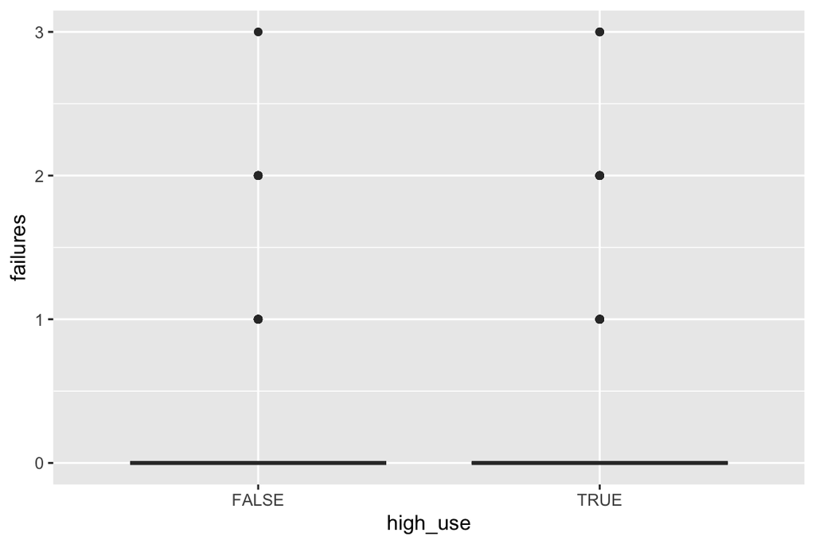

```r
#Create box-plot
g4 <- ggplot(alc, aes(x = high_use, y = failures))

# define the plot as a boxplot and draw it
g4 + geom_boxplot() + ylab("failures")
```

Most students have not failed a class. According to the linear regression model class failures are positively correlated with high alcohol consumption and the association is statistically significant. I have no words for my attempted box plot.

```r
#Install necessary packages
library(tidyverse)
library(GGally)
library(ggplot2)
#install.packages(c("MASS", "corrplot"))
```

# Clustering and classification

## The Boston Data

This week’s assignment utilizes data from the housing values in suburbs of Boston to explore the association of the explanatory variables on the crime rates in different suburbs. The Boston data set has 506 rows of observations representing data from different suburbs. The data set has 14 columns containing following variables: crim :per capita crime rate by town. zn : proportion of residential land zoned for lots over 25,000 sq.ft. indus : proportion of non-retail business acres per town. chas : Charles River dummy variable (= 1 if tract bounds river; 0 otherwise). nox : nitrogen oxides concentration (parts per 10 million). rm : average number of rooms per dwelling. age : proportion of owner-occupied units built prior to 1940. dis : weighted mean of distances to five Boston employment centres. rad : index of accessibility to radial highways. tax : full-value property-tax rate per 10,000 usd. ptratio: pupil-teacher ratio by town. black : proportion of blacks by town lstat : lower status of the population (percent). medv : median value of owner-occupied homes in usd 1000s.

```r
#Download the Boston data
library(MASS)
# load the data
data("Boston")
dim(Boston)
```

```
## [1] 506  14
```

```r
str(Boston)
```

```
## 'data.frame':    506 obs. of  14 variables:
##  $ crim   : num  0.00632 0.02731 0.02729 0.03237 0.06905 ...
##  $ zn     : num  18 0 0 0 0 0 12.5 12.5 12.5 12.5 ...
##  $ indus  : num  2.31 7.07 7.07 2.18 2.18 2.18 7.87 7.87 7.87 7.87 ...
##  $ chas   : int  0 0 0 0 0 0 0 0 0 0 ...
##  $ nox    : num  0.538 0.469 0.469 0.458 0.458 0.458 0.524 0.524 0.524 0.524 ...
##  $ rm     : num  6.58 6.42 7.18 7 7.15 ...
##  $ age    : num  65.2 78.9 61.1 45.8 54.2 58.7 66.6 96.1 100 85.9 ...
##  $ dis    : num  4.09 4.97 4.97 6.06 6.06 ...
##  $ rad    : int  1 2 2 3 3 3 5 5 5 5 ...
##  $ tax    : num  296 242 242 222 222 222 311 311 311 311 ...
##  $ ptratio: num  15.3 17.8 17.8 18.7 18.7 18.7 15.2 15.2 15.2 15.2 ...
##  $ black  : num  397 397 393 395 397 ...
##  $ lstat  : num  4.98 9.14 4.03 2.94 5.33 ...
##  $ medv   : num  24 21.6 34.7 33.4 36.2 28.7 22.9 27.1 16.5 18.9 ...
```

```r
summary(Boston)
```

```
##       crim                zn             indus            chas
##  Min.   : 0.00632   Min.   :  0.00   Min.   : 0.46   Min.   :0.00000
##  1st Qu.: 0.08205   1st Qu.:  0.00   1st Qu.: 5.19   1st Qu.:0.00000
##  Median : 0.25651   Median :  0.00   Median : 9.69   Median :0.00000
##  Mean   : 3.61352   Mean   : 11.36   Mean   :11.14   Mean   :0.06917
##  3rd Qu.: 3.67708   3rd Qu.: 12.50   3rd Qu.:18.10   3rd Qu.:0.00000
##  Max.   :88.97620   Max.   :100.00   Max.   :27.74   Max.   :1.00000
##       nox               rm             age              dis
##  Min.   :0.3850   Min.   :3.561   Min.   :  2.90   Min.   : 1.130
##  1st Qu.:0.4490   1st Qu.:5.886   1st Qu.: 45.02   1st Qu.: 2.100
##  Median :0.5380   Median :6.208   Median : 77.50   Median : 3.207
##  Mean   :0.5547   Mean   :6.285   Mean   : 68.57   Mean   : 3.795
##  3rd Qu.:0.6240   3rd Qu.:6.623   3rd Qu.: 94.08   3rd Qu.: 5.188
##  Max.   :0.8710   Max.   :8.780   Max.   :100.00   Max.   :12.127
##       rad              tax           ptratio          black
##  Min.   : 1.000   Min.   :187.0   Min.   :12.60   Min.   :  0.32
##  1st Qu.: 4.000   1st Qu.:279.0   1st Qu.:17.40   1st Qu.:375.38
##  Median : 5.000   Median :330.0   Median :19.05   Median :391.44
##  Mean   : 9.549   Mean   :408.2   Mean   :18.46   Mean   :356.67
##  3rd Qu.:24.000   3rd Qu.:666.0   3rd Qu.:20.20   3rd Qu.:396.23
##  Max.   :24.000   Max.   :711.0   Max.   :22.00   Max.   :396.90
##      lstat            medv
##  Min.   : 1.73   Min.   : 5.00
##  1st Qu.: 6.95   1st Qu.:17.02
##  Median :11.36   Median :21.20
##  Mean   :12.65   Mean   :22.53
##  3rd Qu.:16.95   3rd Qu.:25.00
##  Max.   :37.97   Max.   :50.00
```